# dstern_hw7

David Stern

October 9, 2015

## Page 304: #2

1. Graph G is not Eulerian. Although it is connected, there are two nodes - {2,5} - that do not have even degree - they both have three edges.
2. If we relaxed the requirement of starting and ending at the same land mass, we would be able to traverse each bridge in this graph exactly once. This is possible because there are two nodes with an odd number of bridges. We do not need to balance the number of times we enter and exit each land mass. The possible pathways for traversing the bridges are:

$Start : 2-1-3-5-6-4-2-3-4-5 : End$ $Start : 2-4-6-5-3-1-2-3-4-5 : End$ $Start : 5-3-1-2-4-6-5-4-3-2 : End$ $Start : 5-6-4-2-1-3-5-4-3-2 : End$

## Page 307: #1

1. $E(G) = {ab,ae,af,bc,bd,cd,de,df,ef}$
2. Edges $ab,bd,bc$ are incident with vertex $b$.
3. Vertices $b$ and $d$ are adjacent to vertex $c$.
4. deg(a) = 3
5. The number of edges in the edge set is $|E(G)|=9$.

## Page 320: #10

Players can start in the following positions:

$Alice\:(A) - 1,2$ $Bonnie\:(B) - 1$ $Courtney\:(C) - 1,2$ $Deb\:(D) - 3,4,5$ $Ellen\:(E) - 2$ $Fay\:(F) - 1$ $Gladys\:(G) - 3,4$ $Hermione\:(H) - 2,3$

We can use the $\textit{igraph}$ package to turn this information into a bipartite graph.

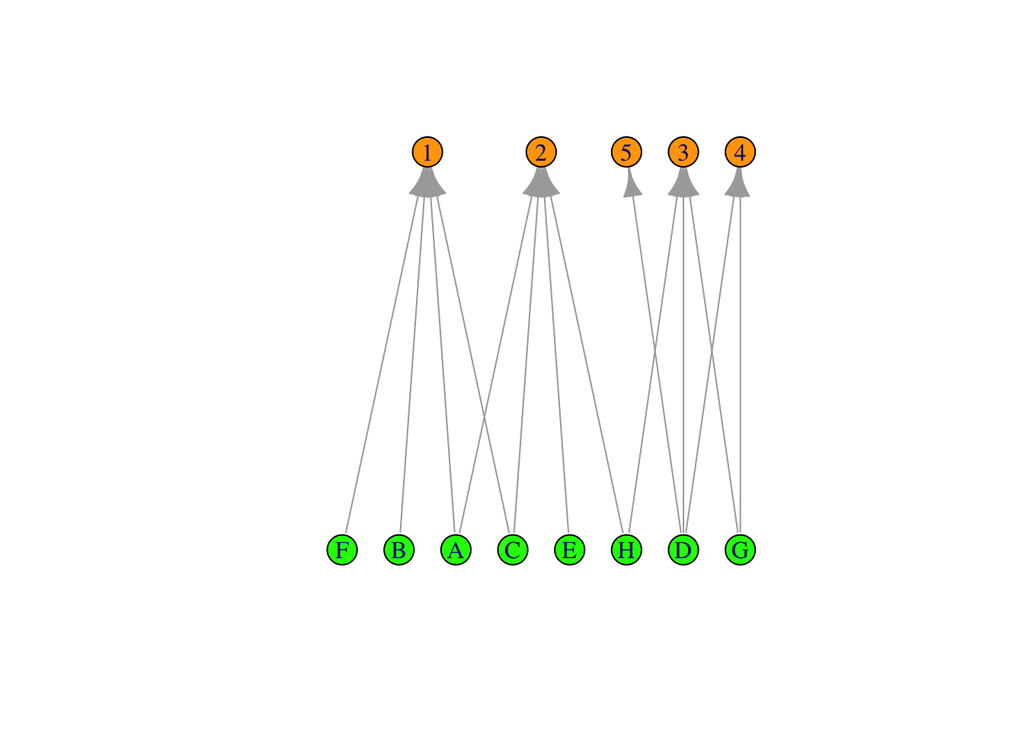

```r
library(igraph)
players <- c("A","B","C","D","E","F","G","H")
positions <- 1:5
edgeList <- data.frame(S1=c("A","A","B","C","C","D","D","D","E","F","G","G","H","H"),
                       S2=c(1,2,1,1,2,3,4,5,2,1,3,4,2,3))
g <- graph.empty()
g <- add.vertices(g,nv=length(players),attr=list(name=players,
                                          type=rep(TRUE,length(players))))
g <- add.vertices(g,nv=length(positions),attr=list(name=positions,
                                type=rep(FALSE,length(positions))))
edgeListVec <- as.vector(t(as.matrix(edgeList)))
g <- add.edges(g,edgeListVec)
plot.igraph(g, layout=layout.bipartite,vertex.color=c("orange","green")[V(g)$type+1])
```

One feasible starting line up is:

$1 - Fay$ $2 - Ellen$ $3 - Hermione$ $4 - Gladys$ $5 - Deb$

If Hermione cannot play in position 3, there is no feasible starting line up. Deb is the only player who can start in position 5, which leaves Gladys the only player who can start in position 4. This leaves Hermione as the only player who can start in position 3.

```
Page 330: #1,#3
Page 338: #4
```